# rutils Package for Simplifying Financial Data Management and Modeling

Jerzy Pawlowski (algoquant)

2020-08-14

The *rutils* package is a library of functions designed for simplifying data management and data modeling, and is used by many other algoquant packages.  
The *rutils* package contains functions for:

- extracting names and columns from time series,
- calculating the end points of a time series,
- applying lags to vectors and matrices,
- calculating row differences of vectors and matrices,
- recursively binding a list of objects into time series,
- recursively applying a function to a list of objects,
- plotting time series with custom axis range and background shading.
- downloading time series data from external sources.

The *rutils* package also includes a dataset with *OHLC* time series data for a portfolio of symbols. The data is contained in an environment called *etf_env*, which includes:

- *sym_bols*: a vector of strings with the portfolio symbols.
- individual time series *VTI*, *VEU*, etc., containing daily *OHLC* prices for all the sym_bols.
- *price_s*: a single *xts* time series containing daily closing prices for all the sym_bols.
- *re_turns*: a single *xts* time series containing daily returns for all the sym_bols.

========

### Installation and loading

How to install *rutils* package from *GitHub*:

```r
install.packages("devtools")
library(devtools)
devtools::install_github(repo="algoquant/rutils")
library(rutils)
```

========

### Datasets

The *rutils* package contains a dataset of daily *OHLC* time series in *xts* format, for a portfolio of stock (ETF) symbols. The time series are contained in an environment called *etf_env*. The data is set up for lazy loading, so it doesn’t require calling `data(etf_data)` to load it before being able to call it.

```r
# show list of ETF time series in etf_env
rutils::etf_env$sym_bols
```

```
##  [1] "DBC"  "IEF"  "VTI"  "EEM"  "XLB"  "GLD"  "USO"  "XLE"  "XLF"  "XLI"
## [11] "VEU"  "VXX"  "IWB"  "XLK"  "IWD"  "SVXY" "VNQ"  "IWF"  "VYM"  "IVW"
## [21] "XLP"  "TLT"  "XLU"  "XLV"  "XLY"  "MTUM"
```

```r
# get first six rows of VTI prices
head(rutils::etf_env$VTI)
```

```
##            VTI.Open VTI.High  VTI.Low VTI.Close VTI.Volume
## 2001-05-31 40.06864 40.25157 39.88571  40.00070    2457200
## 2001-06-01 40.11394 40.38398 39.84390  40.26900    2542200
## 2001-06-04 40.34043 40.50245 40.17840  40.43625    1018200
## 2001-06-05 40.83695 41.11570 40.55820  41.04950     562400
## 2001-06-06 40.84566 41.04253 40.64879  40.71151     278500
## 2001-06-07 40.73765 40.92058 40.55472  40.90315     236700
```

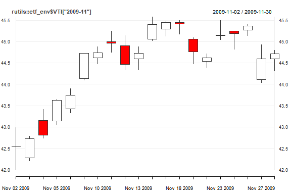

```r
# plot
quantmod::chart_Series(x=rutils::etf_env$VTI["2009-11"])
```

========

### Examples

Download time series data from an external source (by default *OHLC* prices from *YAHOO*), and save it into an environment.

```r
suppressMessages(suppressWarnings(library(rutils)))
# new environment for data
etf_env <- new.env()
# download data and copy it into environment
get_symbols("XOM", env_out=etf_env, start_date="1990-01-01")
# plot
x11()
quantmod::chart_Series(x=rutils::etf_env$XOM["2016/"], TA="add_Vo()", name="XOM stock")
```

Extract the name of an *OHLC* time series from its first column name:

```r
# get name for VTI
get_name(colnames(rutils::etf_env$VTI)[1])
```

```
## [1] "VTI"
```

```r
# get first six rows of VTI prices
head(rutils::etf_env$VTI)
```

```
##            VTI.Open VTI.High  VTI.Low VTI.Close VTI.Volume
## 2001-05-31 40.06864 40.25157 39.88571  40.00070    2457200
## 2001-06-01 40.11394 40.38398 39.84390  40.26900    2542200
## 2001-06-04 40.34043 40.50245 40.17840  40.43625    1018200
## 2001-06-05 40.83695 41.11570 40.55820  41.04950     562400
## 2001-06-06 40.84566 41.04253 40.64879  40.71151     278500
## 2001-06-07 40.73765 40.92058 40.55472  40.90315     236700
```

```r
# get first six rows of price_s
rutils::etf_env$price_s[1:6, 1:4]
```

```
##            DBC IEF VTI EEM
## 1998-12-22  NA  NA  NA  NA
## 1998-12-23  NA  NA  NA  NA
## 1998-12-24  NA  NA  NA  NA
## 1998-12-28  NA  NA  NA  NA
## 1998-12-29  NA  NA  NA  NA
## 1998-12-30  NA  NA  NA  NA
```

```r
# get first six rows of re_turns
rutils::etf_env$re_turns[1:6, 1:4]
```

```
##            DBC IEF VTI EEM
## 1998-12-22  NA  NA  NA  NA
## 1998-12-23  NA  NA  NA  NA
## 1998-12-24  NA  NA  NA  NA
## 1998-12-28  NA  NA  NA  NA
## 1998-12-29  NA  NA  NA  NA
## 1998-12-30  NA  NA  NA  NA
```

Calculate a vector of equally spaced end points for a time series:

```r
# calculate end points with initial stub interval
calc_endpoints(rutils::etf_env$VTI, inter_val=7)
```

Extract columns of prices from an *OHLC* time series:

```r
# get close prices for VTI
get_col(rutils::etf_env$VTI)
# get volumes for VTI
get_col(rutils::etf_env$VTI, col_name="vol")
```

Apply a lag to a vector or matrix:

```r
# lag vector by 2 periods
lag_it(1:10, lag=2)
# lag matrix by negative 2 periods
lag_it(matrix(1:10, ncol=2), lag=-2)
```

Calculate the row differences of a vector or matrix:

```r
# diff vector by 2 periods
diff_it(1:10, lag=2)
# diff matrix by negative 2 periods
diff_it(matrix(1:10, ncol=2), lag=-2)
```

Calculate the time differences of an *xts* time series and pad with zeros:

```r
# calculate time differences over lag by 10 periods
diff_xts(rutils::etf_env$VTI, lag=10)
```

Recursively rbind a list of objects:

```r
# create xts time series
x_ts <- xts(x=rnorm(1000), order.by=(Sys.time()-3600*(1:1000)))
# split time series into daily list
list_xts <- split(x_ts, "days")
# rbind the list back into a time series and compare with the original
identical(x_ts, rutils::do_call_rbind(list_xts))
```

Recursively apply a function to a list of objects:

```r
# create xts time series
x_ts <- xts(x=rnorm(1000), order.by=(Sys.time()-3600*(1:1000)))
# split time series into daily list
list_xts <- split(x_ts, "days")
# rbind the list back into a time series and compare with the original
identical(x_ts, rutils::do_call(rbind, list_xts))
```

Apply a function to a list of objects, merge the outputs into a single object, and assign the object to the output environment:

```r
rutils::do_call_assign(
   func_tion=get_col,
   sym_bols=rutils::etf_env$sym_bols,
   out_put="price_s",
   env_in=etf_env, env_out=new_env)
```

========

### Plotting

Plot an *xts* time series with custom y-axis range and with vertical background shading (using package *quantmod*):

[figure not shown]

```r
chart_xts(rutils::etf_env$VTI["2015-11"], x_11=FALSE,
          name="VTI in Nov 2015", ylim=c(102, 108),
          in_dic=index(rutils::etf_env$VTI["2015-11"]) > as.Date("2015-11-18"))
```

Plot a candlestick plot for an *OHLC* time series, with vertical background shading (using package *quantmod*):

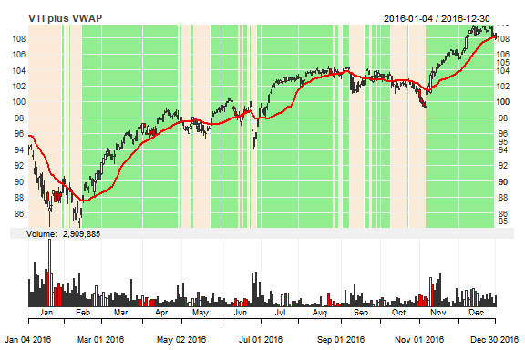

```r
# select VTI
oh_lc <- rutils::etf_env$VTI
# calculate volume-weighted average price
v_wap <- rutils::roll_sum(x_ts=oh_lc[, 4]*oh_lc[, 5], look_back=22)
volume_rolling <- rutils::roll_sum(x_ts=oh_lc[, 5], look_back=22)
v_wap <- v_wap/volume_rolling
v_wap[is.na(v_wap)] <- 0
# plot candlesticks with vertical background shading and trading volume.
rutils::chart_xts(oh_lc["2016"], x_11=FALSE,
                  name="VTI plus VWAP",
                  TA="add_Vo(); add_TA(v_wap['2016'], col='red', lwd=2, on=1)",
                  in_dic=(oh_lc["2016", 4] > v_wap["2016"]))
```

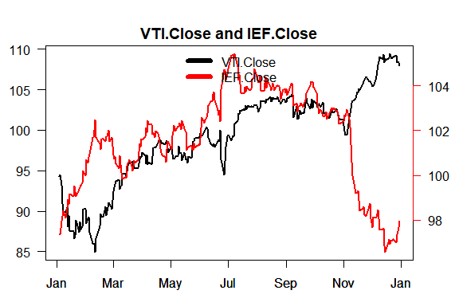

```r
rutils::chart_xts2y(cbind(quantmod::Cl(rutils::etf_env$VTI),
                          quantmod::Cl(rutils::etf_env$IEF))["2016"],
                    x_11=FALSE)
```

Plot an interactive dygraphs candlestick plot with background shading (using package *dygraphs*):

```r
oh_lc <- rutils::etf_env$VTI
v_wap <- TTR::VWAP(price=quantmod::Cl(oh_lc), volume=quantmod::Vo(oh_lc), n=20)
oh_lc <- cbind(oh_lc[, c(1:4)], v_wap)["2016"]
rutils::chart_dygraph(oh_lc, in_dic=(oh_lc[, 4] > v_wap))
```

[interactive chart not shown]